# Selling SPY Weeklys: 2014 - 2018

Threshold Delta-Hedging

Pritam Dalal

February 2, 2019

In our initial 5-year backtest of selling SPY weeklys we considered two delta-hedging strategies:

1. naked options (doing nothing)
2. rebalancing daily

In this analysis we consider an alternative approach to delta-hedging. In particular, we set a threshold between 0% and 100%, and we rebalance the delta-hedge whenever the absolute net-delta of the position exceeds this threshold.

The the naked strategy and daily delta-hedging are two extremes of this threshold approach. Naked option selling corresponds to a threshold of 100%; daily delta-hedging corresponds to a threshold of 0%.

#### Visualizing Performance as a Function of Threshold

In this section we calculate three key performance metrics for threshold levels ranging from 0% to 100%. The three metrics we consider are:

1. annualized average PNL (the numerator of the Sharpe-Ratio)
2. annualized standard deviation of PNL (the denominator of the Sharpe-Ratio)
3. Sharpe-Ratio.

The graphs of each are given below, followed by a few words of commentary:

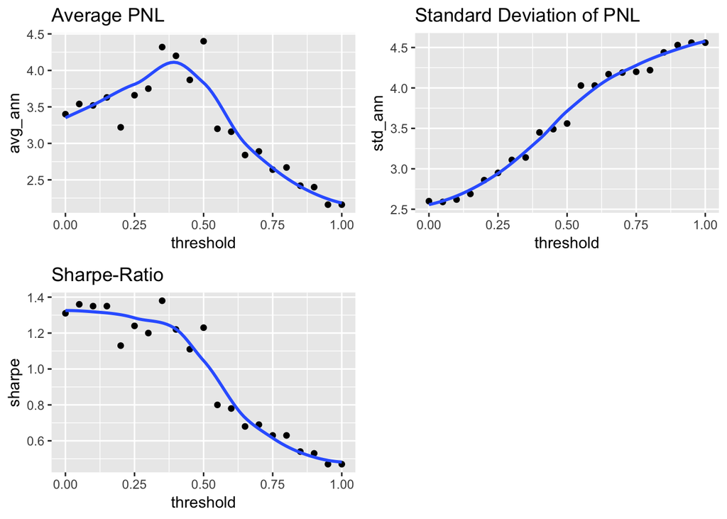

1. The impact on standard deviation makes strong intuitive sense. As we go from more frequent (0%) to less frequent (100%) hedging, the variability of the PNL increases.
2. The impact on average returns has intuitive appeal as well. If we hedge too frequently (approaching 0%), we lock-in losses even when the underlying is mostly range bound. If we hedge too *in*frequently (approaching 100%), we suffer large losses when the market moves a lot. It’s not surprising that there is a sweet spot in the middle, which in our data is a threshold of 40%-50%.
3. The Sharpe-Ratio graph has an interesting feather: there is a bifurcation between thresholds in the range of 0%-50% and those in the range of 50%-100%. The 0%-50% group has Sharpes ranging from 1.11 to 1.38, with an average of 1.26. The 50%-100% group has Sharpes ranging from 0.47 to 0.80, with an average of 0.62.

#### Dual Scatter Plots

In this section we look at the two scatter plots, each with a wrinkle. Both scatter plots graph the average annual PNL against the annual standard deviation of the pnl - one pair for corresponding to each threshold. However, instead of simply plotting a dot, we instead plot the threshold amount (left graph) and the Sharpe-Ratio (right graph). This allows us to include three dimensions of data on a 2-D plot.

Because of how the axes of the graphs are laid out, the highest Sharpe-Ratios are in the bottom right, and the lowest Sharpe-Ratios are in the upper left.

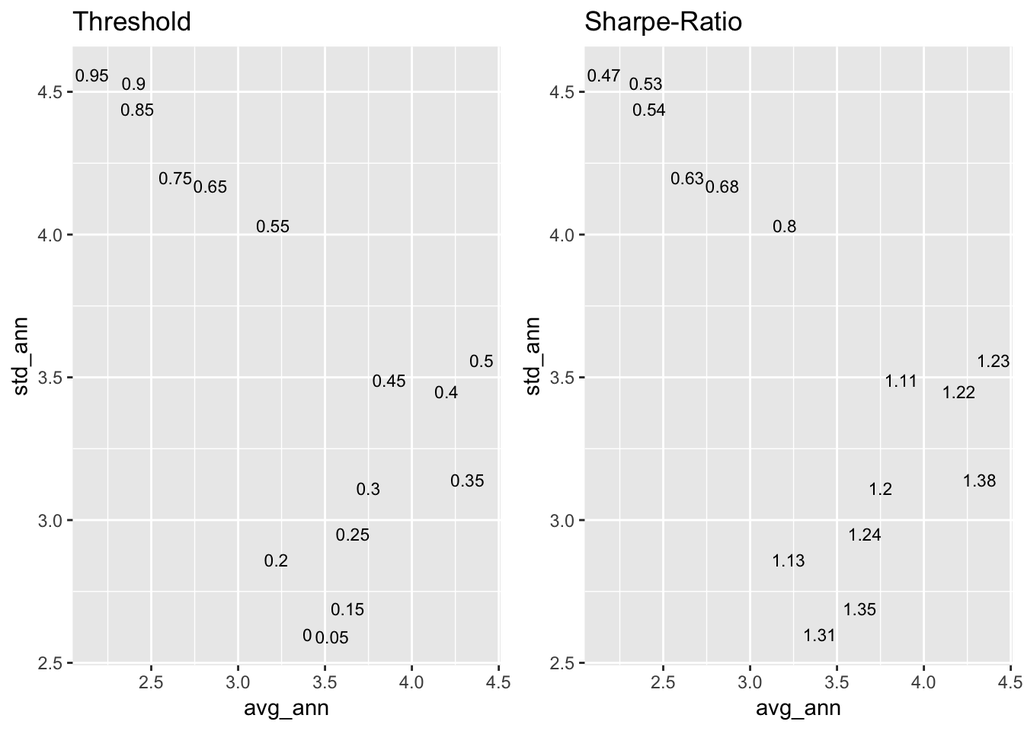

Based on these two graphs, it seems that a threshold of 35%-50% has the best combination of high a Sharpe-Ratio, along with strong returns. This mirrors the *sweet spot* we observed in the previous section.

#### Conclusion & Recommendation

Based on this analysis, I would recommend a 50%-threshold delta-hedging strategy. I suspect performance would be improved if this strategy is automated so that hedging can occur intraday, in the event of large directional moves.